# Time Series Analysis

### Exercise 12.3

Let's see how well an ARIMA model fits production from hydroelectric generators in the United States. Here's what the time series looks like from 2001 to 2024.

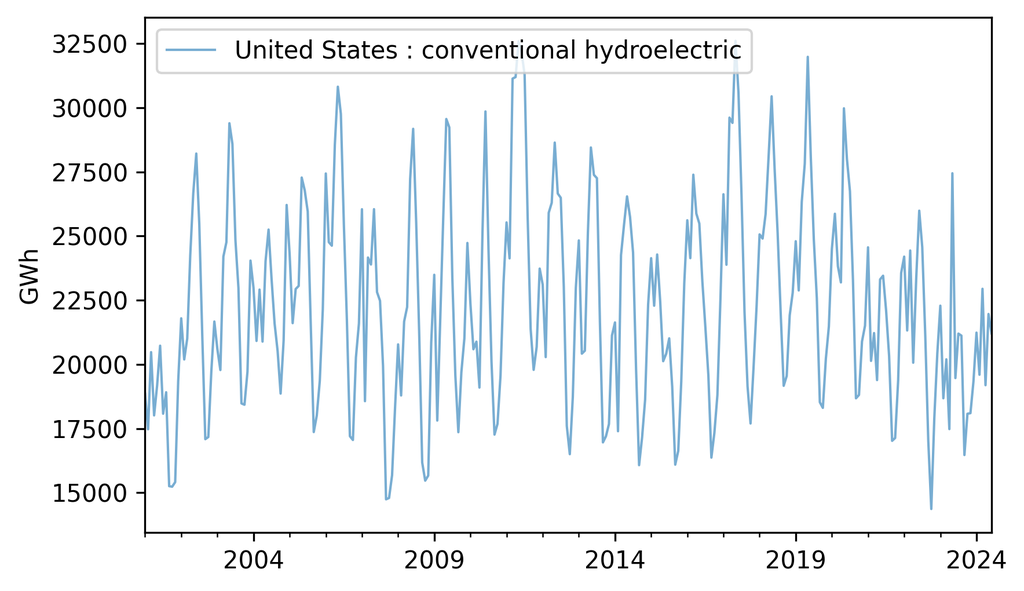

```python
hydro = elec["United States : conventional hydroelectric"]
hydro.plot(**actual_options)
decorate(ylabel="GWh")
```

Fit a SARIMA model to this data with a seasonal period of 12 months. Experiment with different lags in the autoregression and moving average parts of the model and see if you can find a combination that maximizes the $R^2$ value of the model. Generate a five-year forecast and plot it along with its confidence interval.

NOTE: Depending on what lags you include in the model, you might find that the first 12 to 24 elements of the fitted values are not reliable. You might want to remove them before plotting or computing $R^2$.

```python
# Solution

model = tsa.ARIMA(hydro, order=([1, 6], 0, [6]), seasonal_order=(0, 1, 0, 12))
results_arima = model.fit()
display_summary(results_arima)
```

|  | coef | std err | z | P>\|z\| | [0.025 | 0.975] |
| --- | --- | --- | --- | --- | --- | --- |
| ar.L1 | 0.5387 | 0.039 | 13.680 | 0.000 | 0.461 | 0.616 |
| ar.L6 | -0.4041 | 0.046 | -8.722 | 0.000 | -0.495 | -0.313 |
| ma.L6 | 0.9405 | 0.043 | 22.009 | 0.000 | 0.857 | 1.024 |
| sigma2 | 4.437e+06 | 3.58e+05 | 12.396 | 0.000 | 3.74e+06 | 5.14e+06 |

```python
# Solution

n_missing = 24
fittedvalues = results_arima.fittedvalues[n_missing:]
```

```python
# Solution

resid = hydro - fittedvalues
R2 = 1 - resid.var() / nuclear.var()
R2
```

```
np.float64(0.8057348447529014)
```

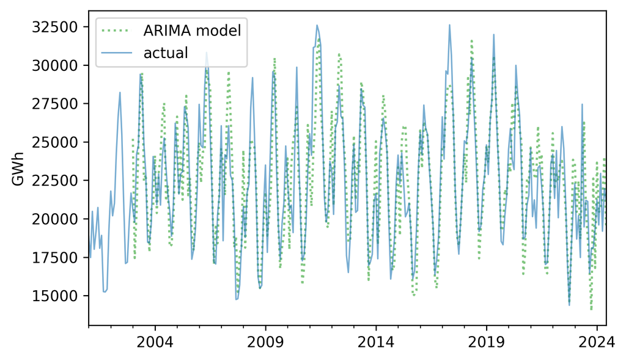

```python
# Solution

fittedvalues.plot(label="ARIMA model", **pred_options)
hydro.plot(label="actual", **actual_options)
decorate(ylabel="GWh")
```

```python
# Solution

forecast = results_arima.get_forecast(steps=60)
```

```python
# Solution

forecast_mean = forecast.predicted_mean
forecast_ci = forecast.conf_int()
forecast_ci.columns = ["lower", "upper"]
```

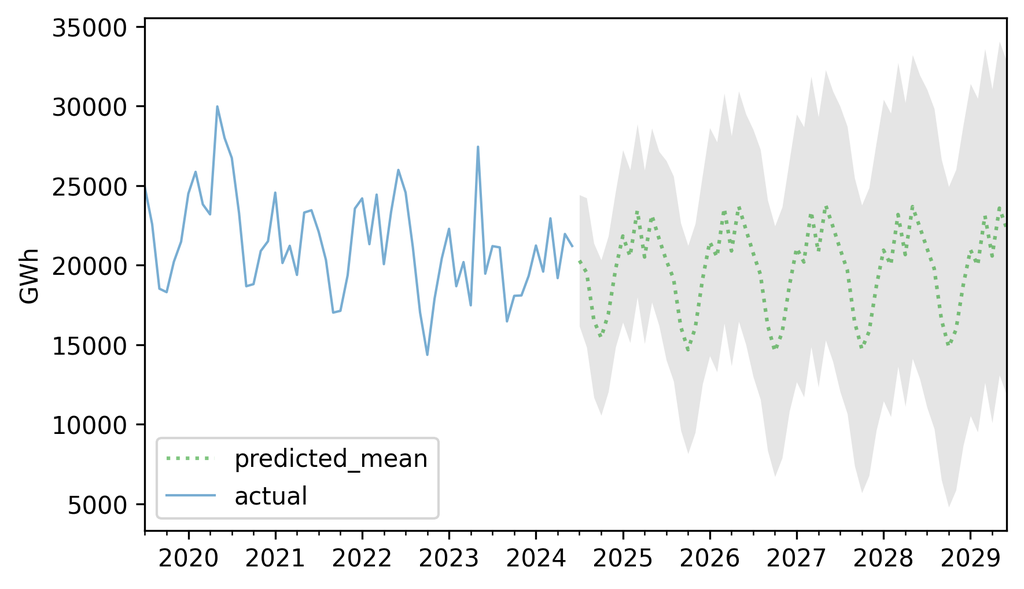

```python
# Solution

recent = hydro.iloc[-60:]

forecast_mean.plot(**pred_options)
plt.fill_between(
    forecast_ci.index,
    forecast_ci.lower,
    forecast_ci.upper,
    lw=0,
    color="gray",
    alpha=0.2,
)
recent.plot(label="actual", **actual_options)
decorate(ylabel="GWh")
```

Commentary

The SARIMA model fitted here, `order=([1, 6], 0, [6])` with `seasonal_order=(0, 1, 0, 12)`, deserves element-by-element unpacking because each number reflects a modelling decision.

The `order=([1, 6], 0, [6])` specifies the non-seasonal AR and MA structure applied to the differenced series. Including lags 1 and 6 in the AR component means the model predicts $\tilde{y}_t$ from the values six months ago and one month ago — plausible for hydroelectric generation, which depends on snowpack and rainfall patterns that carry multi-month memory. The MA lag at 6 models the persistence of forecast errors at a half-year horizon.

The `get_forecast(steps=60)` call uses the fitted state-space representation of the ARIMA model (via a Kalman filter) to propagate the model forward 60 steps. Crucially, the confidence interval widens with the forecast horizon because prediction error variance accumulates: each step adds the one-step-ahead innovation variance $\hat\sigma^2$, so the interval grows roughly as $\sqrt{h}$ for an AR(1)-type process. The `conf_int()` method returns the 95% interval by default, derived from the asymptotic normality of the forecast distribution — an assumption that may be too optimistic if the residuals are fat-tailed or if the model is misspecified.

The `n_missing=24` burn-in period reflects a practical constraint: seasonal differencing consumes 12 observations, and the longest non-seasonal lag (6 in both AR and MA) consumes up to 6 more, leaving the first 18 to 24 fitted values unreliable. Trimming them before computing $R^2$ avoids artificially inflating or deflating the fit statistic due to initialisation artefacts.